# The role of Official Development Assistance in human capital development, 1985-2016

Aerim Kang, Athieno Gloria, Awah Favour Matthew, and Hana Lee

31/07/2020

## Introduction

The end of the cold war between the U.S. and the Soviet Union resulted in the redirection of foreign aids from political agenda to support for new independent states in Africa, Asia, and the Latin America. Some of these aid-recipients have successfully developed into aid donors and are currently members of the Economic Co-operation and Development (OECD). This efforts for post-war relief led to the establishment of international organizations like the World Health Organization (WHO), United Nations Children Funds (UNISEF), Food and Agricultural Organization (FAO) that represent international concessions to alleviate poverty, promote equality and human rights (Nakyon, 2017). The official development assistance (ODA) refers to concessional aids flowing from members of the Organization for Economic Co-operation and Development (OECD) to recipient countries on the development assistance committee (DAC) list targeted towards specific areas of socio-economic growth such as education and health. Many developing economies will require such aids to meet-up with the development agenda such as the sustainable development goals. According to empirical studies by Kyne (2008), official development assistance (ODA) was found to have a significant positive relationship with several indices of human development particularly, when funds were targeted towards socio-economic development. Similarly, ODA allocated for basic and post-secondary education were significantly associated with educational development (Kyne 2008). Conversely, aid has been shown to significantly decrease child mortality in poor regions of Nigeria especially in areas with proximity to aid projects (Kotsadam, 2017). Findings by Patrinos, and Psacharopoulos (2011) shows that average years of schooling increased simultaneously across several regions of the world by 2 to 3 additional years i.e., in a comparable fashion between 1970 and 2000. Findings in that study showed that average years of schooling across the world has increased in a steady fashion between o.6 and 0.7 years per decade since 1950. The findings suggest that both developing and developed economies have not relented in their investment in education. Matching the pace of developed countries can only be possible for the developing nations as a result of aid through ODA funding targeted at human capital development through education (Patrinos & Psacharopoulos, 2011).

##AIM OF THE STUDY This study seeks to investigate the relationship between ODA and socio-economic variables of Education in developing countries.

## Research questions

How significant is the relationship between education attainment and economic growth(GDP per Capita)? Is there a significant difference in the amount of ODA among developing countries? Does percentage contribution to ODA fund vary significantly among the top 5 OECD members?

##Method: Data Collection: ODA data was collected from World Bank data (World Development Indicators- WDI) from 1985 to 2016, Mean years of schooling data was obtained from World In Data while School Attainment data was obtained from WDI.

### The first section of the Dashboard

```
## [1] 7607   32
```

The data was obtained from world bank. there are 7607 observations with 32 variables.

```
## # A tibble: 7,607 x 32
##    iso3  country  year edupriFE edupriFM edupriMA labadvFE labadvFM labadvMA
##    <chr> <chr>   <dbl>    <dbl>    <dbl>    <dbl>    <dbl>    <dbl>    <dbl>
##  1 ABW   Aruba    1985       NA       NA       NA       NA       NA       NA
##  2 ABW   Aruba    1986       NA       NA       NA       NA       NA       NA
##  3 ABW   Aruba    1987       NA       NA       NA       NA       NA       NA
##  4 ABW   Aruba    1988       NA       NA       NA       NA       NA       NA
##  5 ABW   Aruba    1989       NA       NA       NA       NA       NA       NA
##  6 ABW   Aruba    1990       NA       NA       NA       NA       NA       NA
##  7 ABW   Aruba    1991       NA       NA       NA       NA       NA       NA
##  8 ABW   Aruba    1992       NA       NA       NA       NA       NA       NA
##  9 ABW   Aruba    1993       NA       NA       NA       NA       NA       NA
## 10 ABW   Aruba    1994       NA       NA       NA       NA       NA       NA
## # ... with 7,597 more rows, and 23 more variables: ODAProvcons <dbl>,
## #   ODAProvcurr <dbl>, ODAProvperGNI <dbl>, ODARecvpergov <dbl>, ODA <dbl>,
## #   Region1 <chr>, Region2 <chr>, Continent <chr>, GDPgrowth <dbl>,
## #   GDPpercap <dbl>, fertility <dbl>, lifeExpFE <dbl>, lifeExpFM <dbl>,
## #   lifeExpMA <dbl>, mortalityFE <dbl>, mortalityIF <dbl>, mortalityIFFE <dbl>,
## #   mortalityIFMA <dbl>, mortalityMA <dbl>, schooling <dbl>, id <dbl+lbl>,
## #   ln_GDPpercap <dbl>, ODARecvpergov2 <dbl>
```

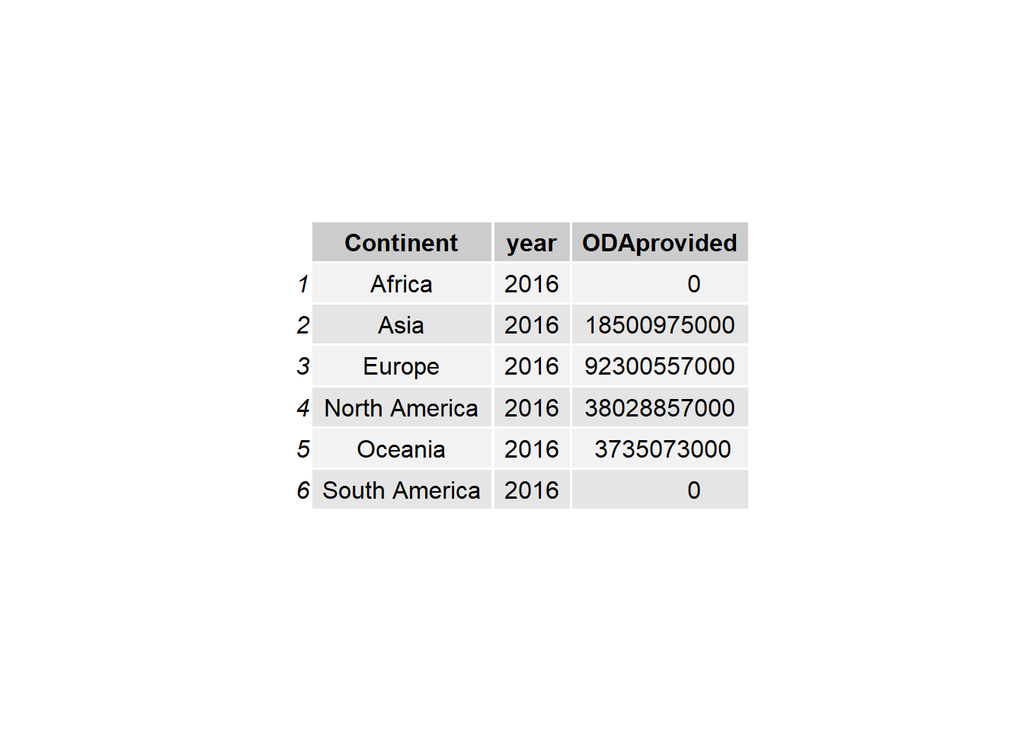

The table above shows continents that provided Official Development Assistance(ODA) to developing countries in 2016. Europe was the greatest provider of ODA, they contributed $92,300,557,000, followed by NorthAmerica ,$38,028,857,000, then followed by Asia $18,500,975,000 and lastly Oceania, $3,735,073,000. However, no ODA was obtained from Africa and South America.

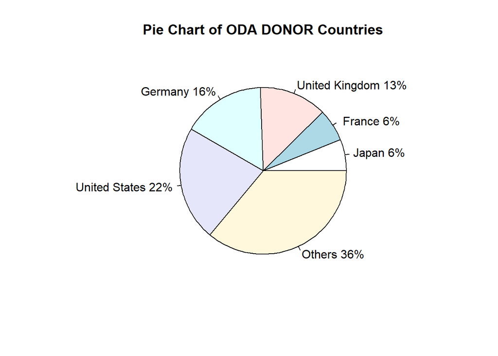

To have a better understanding of ODA provision in 2016, the piechart above shows the Top 5 countries that provided ODA to developing countries.United States was the highest provider followed by Germany and the least provider was Japan.

```
## # A tibble: 15 x 2
##    country                  ODARecvpergov
##    <chr>                            <dbl>
##  1 Central African Republic         308.
##  2 West Bank and Gaza               233.
##  3 Malawi                           127.
##  4 Rwanda                            71.7
##  5 Mali                              69.8
##  6 Micronesia, Fed. Sts.             68.8
##  7 Mozambique                        68.6
##  8 Vanuatu                           64.7
##  9 Tonga                             64.4
## 10 Madagascar                        59.4
## 11 Burkina Faso                      54.5
## 12 Ethiopia                          54.5
## 13 Uganda                            53.4
## 14 Afghanistan                       51.4
## 15 Kiribati                          48.0
```

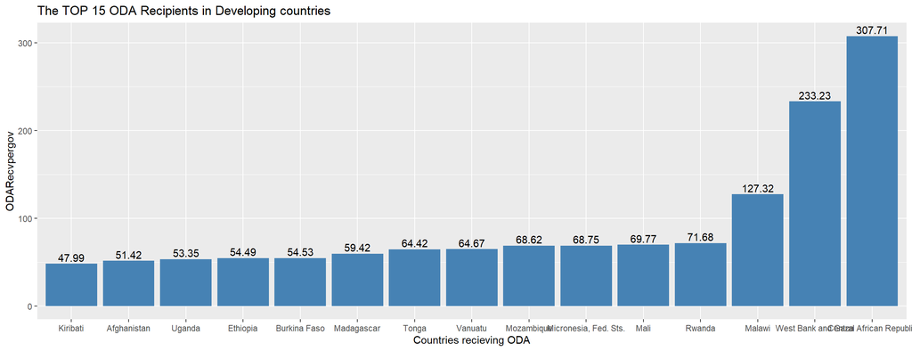

The barplot illustrates the top 15 countries that had the highest ratio of ODA to government expenses in 2016. Central African Republic had the highest ratio of ODA to government expenses, 307.71 followed by West Bank and Gaza(Palestine), 233.23 and then Malawi, 127.32. The three countries(Central African Republic,West Bank and Gaza and Malawi)received a very high contribution of ODA as compared to their government expense since their ODA percentage contribution was over 100%. Additionally, the other countries of Mali, Rwanda,Micronesia, Fed. Sts,Mozambique,Vanuatu,Tonga ,Madagascar,Burkina Faso,Ethiopia,Uganda,Afghanistan and Kiribati received an ODA contribution between 47% to 72%.This implies that the ODA received was less that the government contribution the country’s economies.

##References

Kotsadam, A., Gudrun, O., Rustad, S. & Tollefsen, A. & Urdal, H. (2018). Development aid and infant mortality. Micro-level evidence from Nigeria. World Development. 105. 59-69. 10.1016/j.worlddev.2017.12.022. Kyne, Dean. (2008). An empirical investigation of relationships between official development assistance (ODA) and human and educational development. International Journal of Social Economics. 35. 202-221. 10.1108/03068290810847879. Nakyon, L. (2017). Korea’s ODA white paper: Beautiful Sharing Wonderful Growing. Patrinos, A. H. and Psacharopoulos, G. (2011). Education Past, Present and Future Global Challenges. Policy Research Working Paper 5616. The World Bank Human Development Network Education Team, pg. 5